# 2_Labels_data_aug

## In the following notebook, class weighting and data augmentation for the labels "Excitement" and "Disappointment" are tested.

The reason for applying augmentation only to part of the dataset is the difficulty in distinguishing between the two labels.  
The idea is that due to the imbalance in the number of samples per label, the model may not be sufficiently trained to differentiate between them.  
By augmenting only these two labels, the increased amount of data could improve the model's ability to distinguish between them.

```python
!pip install transformers datasets accelerate
!pip install librosa
```

[output not shown]

[output not shown]

```python
from transformers import AutoFeatureExtractor, ASTForAudioClassification, AutoModelForAudioClassification
from datasets import load_dataset, Dataset
import torch
import sklearn
import json, os, time, glob

import numpy as np
import librosa
from collections import defaultdict
from pprint import pprint

from transformers import Trainer

import sklearn.metrics as skm
from sklearn.model_selection import train_test_split
from sklearn.utils.class_weight import compute_class_weight
from sklearn.metrics import classification_report, confusion_matrix
import torch.nn as nn
import matplotlib.pyplot as plt
import seaborn as sns

import random
```

```python
data_path = "16k_data"
glob.glob(data_path + '/**')
```

```
['16k_data/meta.json', '16k_data/training_25112024.npz']
```

### In the following JSON, it can be seen that the labels 'Disappointment' and 'Excitement' are encoded as 2 and 1, respectively.

```python
arrays = np.load(f'{data_path}/training_25112024.npz')
meta = json.load(open(f'{data_path}/meta.json', 'r'))

pprint(meta)
```

```
{'labelfile': 'project-6-at-2024-11-23-15-47-9e286610.json',
 'labels': {'Boring': 4,
            'Celebration': 3,
            'Chanting/Singing': 0,
            'Disappointment': 2,
            'Excitement': 1},
 'sample_rate': 16000,
 'snippet_sec': 1,
 'sources': ['HKvsBHUTAN001.wav',
             'HKvsBHUTAN002.wav',
             'HKvsBRUNEI.wav',
             '2023716VS.wav',
             '1ExcitementDisappointment.MP3.wav',
             '2ExcitementCelebration.MP3.wav',
             '3Boring.MP3.wav',
             'Boring_001.wav',
             'Celebration_001.MP3.wav',
             'Celebration_002.MP3.wav',
             'Combine.MP3.wav',
             'Disappointment_001.wav',
             'Disappointment_002.wav',
             'Excitement_001.MP3.wav',
             'HongKongvsSingaporeInternationalFriendlyMongkokStadium.wav',
             'test.MP3.wav']}
```

## Data Augmentation

Three different methods are used to augment the audio files:

- Noise
- Pitch shifting
- Time stretching

A function randomly selects which of the three methods to apply.  
This approach follows best practices, as previous attempts using only one method resulted in poorer performance.

```python
# Beispiel für Data Augmentation auf einem Audiodatensatz
def add_noise(audio, noise_factor=0.005):
    noise = np.random.randn(len(audio)) * noise_factor
    augmented_audio = audio + noise
    return np.clip(augmented_audio, -1.0, 1.0)  # Clips the audio between -1 and 1

def pitch_shift(audio, sr, shift=2):
    return librosa.effects.pitch_shift(audio, sr=sr, n_steps=shift)

def time_stretch(audio, rate=1.1):
    return librosa.effects.time_stretch(audio, rate=rate)

# Beispiel eines Augmentierungsprozesses
def augment_audio(audio, sr):
    augmentation_type = random.choice(['noise', 'pitch', 'stretch'])

    if augmentation_type == 'noise':
        return add_noise(audio)
    elif augmentation_type == 'pitch':
        return pitch_shift(audio, sr)
    elif augmentation_type == 'stretch':
        return time_stretch(audio)

    return audio
```

## Model

```python
model_name = "MIT/ast-finetuned-audioset-10-10-0.4593"
device = 'cuda'

feature_extractor = AutoFeatureExtractor.from_pretrained(model_name)
model2train = AutoModelForAudioClassification.from_pretrained(
    model_name,
    num_labels = len(meta['labels']),
    label2id = meta['labels'],
    id2label = {v:k for k,v in meta['labels'].items()},
    ignore_mismatched_sizes = True
)
```

```
Some weights of ASTForAudioClassification were not initialized from the model checkpoint at MIT/ast-finetuned-audioset-10-10-0.4593 and are newly initialized because the shapes did not match:
- classifier.dense.bias: found shape torch.Size([527]) in the checkpoint and torch.Size([5]) in the model instantiated
- classifier.dense.weight: found shape torch.Size([527, 768]) in the checkpoint and torch.Size([5, 768]) in the model instantiated
You should probably TRAIN this model on a down-stream task to be able to use it for predictions and inference.
```

```python
preprocessed_audio = feature_extractor(
    arrays['X'],
    sampling_rate = meta['sample_rate'],
    return_tensors = "pt"
)
```

## Application of Augmentation

To ensure that only the labels "Disappointment" and "Excitement" are augmented, a check is performed for `1` and `2`:  
`if label in [1, 2]:`

```python
import numpy as np
import torch
from datasets import Dataset

def process_and_augment_dataset(arrays_X, arrays_y, arrays_groups, meta, feature_extractor, labels_to_augment, n_augments=5):
    augmented_audio_data = []
    augmented_labels = []
    augmented_groups = []

    sr = meta['sample_rate']

    for i, audio in enumerate(arrays_X):
        label = arrays_y[i]
        group = arrays_groups[i]

        # Originale Daten hinzufügen
        preprocessed_audio = feature_extractor(
            audio,
            sampling_rate=sr,
            return_tensors="pt"
        )
        augmented_audio_data.append(preprocessed_audio['input_values'])
        augmented_labels.append(label)  # Originales Label
        augmented_groups.append(group)

        # Augmentierung nur für Labels 1 und 2
        if label in labels_to_augment:
            for _ in range(n_augments):
                # Augmentierung auf rohen Audiodaten anwenden
                augmented_audio = augment_audio(audio, sr)

                # Feature-Extraktion nach der Augmentierung
                preprocessed_audio = feature_extractor(
                    augmented_audio,
                    sampling_rate=sr,
                    return_tensors="pt"
                )

                augmented_audio_data.append(preprocessed_audio['input_values'])
                augmented_labels.append(label)  # Augmentiertes Label
                augmented_groups.append(group)  # Ursprung der Daten

    # Alle augmentierten Eingabewerte kombinieren
    input_values = torch.cat(augmented_audio_data, dim=0)

    hf_dataset = Dataset.from_dict({
        "input_values": input_values.numpy(),  # In NumPy-Array umwandeln
        "label": np.array(augmented_labels)  # Labels als NumPy-Array
    })

    augmented_groups = np.array(augmented_groups) # groups als NumPy-Array

    return hf_dataset, augmented_groups
arrays = np.load('16k_data/training_25112024.npz')

# Extract arrays X, y, and groups
arrays_X = arrays['X']
arrays_y = arrays['y']
arrays_groups = arrays['groups']
#hf_dataset, augmented_groups = process_and_augment_dataset(arrays, meta, feature_extractor, 1)
hf_dataset, augmented_groups = process_and_augment_dataset(arrays_X, arrays_y, arrays_groups, meta, feature_extractor, [1, 2])
# bei <1 entstehen eventuell duplikate
```

## Visualization of Label Distribution

Although there is still an imbalance in the distribution, it is not as pronounced as before.

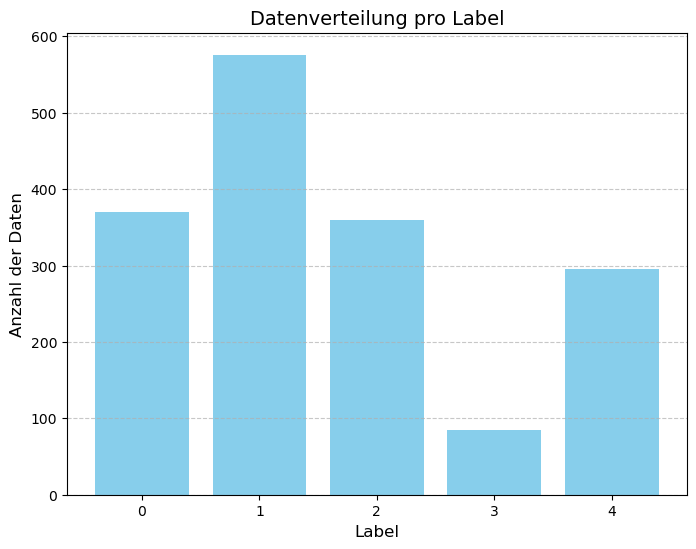

```python
import matplotlib.pyplot as plt
from collections import Counter

def plot_label_distribution(hf_dataset):
    # Labels aus dem Dataset extrahieren
    labels = hf_dataset["label"]

    # Häufigkeit der Labels zählen
    label_counts = Counter(labels)

    # Balkendiagramm erstellen
    plt.figure(figsize=(8, 6))
    plt.bar(label_counts.keys(), label_counts.values(), color='skyblue')
    plt.xlabel("Label", fontsize=12)
    plt.ylabel("Anzahl der Daten", fontsize=12)
    plt.title("Datenverteilung pro Label", fontsize=14)
    plt.xticks(ticks=list(label_counts.keys()), labels=list(label_counts.keys()), fontsize=10)
    plt.grid(axis='y', linestyle='--', alpha=0.7)
    plt.show()

# Plot erstellen
plot_label_distribution(hf_dataset)
```

```python
# preprocessed_audio = feature_extractor(
#     arrays['X'],
#     sampling_rate = meta['sample_rate'],
#     return_tensors = "pt"
# )

# hf_dataset = Dataset.from_dict({
#     "input_values": preprocessed_audio['input_values'],
#     "label": arrays['y'],
# })
```

```python
from sklearn.model_selection import GroupShuffleSplit

gss = GroupShuffleSplit(n_splits=10, train_size=.8, random_state=42)
gss.get_n_splits()

for i, (train_index, test_index) in enumerate(gss.split(X=hf_dataset["input_values"], y=hf_dataset["label"], groups=augmented_groups)):
    print(f"Fold {i}:")
    print(f"  Train: source={set(augmented_groups[train_index])}")
    print(f"  Test:  source={set(augmented_groups[test_index])}")
```

```
Fold 0:
  Train: source={np.int64(2), np.int64(3), np.int64(4), np.int64(6), np.int64(7), np.int64(8), np.int64(9), np.int64(10), np.int64(11), np.int64(12), np.int64(13), np.int64(15)}
  Test:  source={np.int64(0), np.int64(1), np.int64(5), np.int64(14)}
Fold 1:
  Train: source={np.int64(0), np.int64(1), np.int64(3), np.int64(4), np.int64(5), np.int64(7), np.int64(9), np.int64(10), np.int64(11), np.int64(12), np.int64(14), np.int64(15)}
  Test:  source={np.int64(8), np.int64(2), np.int64(13), np.int64(6)}
Fold 2:
  Train: source={np.int64(0), np.int64(2), np.int64(3), np.int64(4), np.int64(6), np.int64(7), np.int64(9), np.int64(10), np.int64(11), np.int64(12), np.int64(14), np.int64(15)}
  Test:  source={np.int64(8), np.int64(1), np.int64(13), np.int64(5)}
Fold 3:
  Train: source={np.int64(1), np.int64(3), np.int64(4), np.int64(6), np.int64(7), np.int64(8), np.int64(9), np.int64(10), np.int64(11), np.int64(12), np.int64(13), np.int64(15)}
  Test:  source={np.int64(0), np.int64(2), np.int64(5), np.int64(14)}
Fold 4:
  Train: source={np.int64(0), np.int64(1), np.int64(2), np.int64(3), np.int64(5), np.int64(6), np.int64(7), np.int64(8), np.int64(9), np.int64(11), np.int64(12), np.int64(13)}
  Test:  source={np.int64(10), np.int64(4), np.int64(14), np.int64(15)}
Fold 5:
  Train: source={np.int64(0), np.int64(1), np.int64(3), np.int64(5), np.int64(6), np.int64(7), np.int64(9), np.int64(10), np.int64(11), np.int64(13), np.int64(14), np.int64(15)}
  Test:  source={np.int64(8), np.int64(2), np.int64(4), np.int64(12)}
Fold 6:
  Train: source={np.int64(0), np.int64(1), np.int64(4), np.int64(5), np.int64(6), np.int64(7), np.int64(8), np.int64(9), np.int64(10), np.int64(11), np.int64(12), np.int64(15)}
  Test:  source={np.int64(2), np.int64(3), np.int64(13), np.int64(14)}
Fold 7:
  Train: source={np.int64(0), np.int64(1), np.int64(2), np.int64(3), np.int64(4), np.int64(6), np.int64(7), np.int64(8), np.int64(10), np.int64(12), np.int64(14), np.int64(15)}
  Test:  source={np.int64(9), np.int64(13), np.int64(11), np.int64(5)}
Fold 8:
  Train: source={np.int64(0), np.int64(2), np.int64(4), np.int64(5), np.int64(6), np.int64(7), np.int64(9), np.int64(10), np.int64(12), np.int64(13), np.int64(14), np.int64(15)}
  Test:  source={np.int64(8), np.int64(1), np.int64(3), np.int64(11)}
Fold 9:
  Train: source={np.int64(0), np.int64(2), np.int64(3), np.int64(4), np.int64(6), np.int64(7), np.int64(8), np.int64(9), np.int64(10), np.int64(11), np.int64(14), np.int64(15)}
  Test:  source={np.int64(1), np.int64(13), np.int64(12), np.int64(5)}
```

```python
import transformers

batch_size = 8
args = transformers.TrainingArguments(
    f'{model_name.split("/")[-1]}-ft_stadium',

    learning_rate=1e-5,
    warmup_ratio=0.1,


    eval_strategy = "steps",
    eval_steps = 10,
    logging_steps=10,

    save_strategy = "epoch",
    per_device_train_batch_size=batch_size,
    per_device_eval_batch_size=batch_size,

    gradient_accumulation_steps=4,
    num_train_epochs=5,
    load_best_model_at_end=False,
    push_to_hub=False,
)
```

```python
# select one train test split
(train_index, test_index) = next(gss.split(X=hf_dataset["input_values"], y=hf_dataset["label"], groups=augmented_groups))
```

```python
train_ds = hf_dataset.select(train_index)
```

```python
class CustomTrainer(Trainer):
    def __init__(self, *args, class_weights=None, **kwargs):
        super().__init__(*args, **kwargs)
        self.class_weights = class_weights

    def compute_loss(self, model, inputs, return_outputs=False, **kwargs):
        labels = inputs.pop("labels").to(torch.long)  # Labels in int64 konvertieren
        outputs = model(**inputs)
        logits = outputs.logits.to(torch.float32)  # Logits in float32 konvertieren

        # Loss-function with class weights
        loss_fn = nn.CrossEntropyLoss(weight=self.class_weights)
        loss = loss_fn(logits, labels)

        return (loss, outputs) if return_outputs else loss

    def compute_metrics(pred):
        labels = pred.label_ids
        preds = pred.predictions.argmax(-1)

        metrics = {
            'accuracy': skm.accuracy_score(labels, preds),
            'macro_f1': skm.f1_score(labels, preds, average='macro'),
            'weighted_f1': skm.f1_score(labels, preds, average='weighted')
        }

        return metrics
```

```python
class_weights = compute_class_weight(
    class_weight="balanced",
    classes=np.unique( hf_dataset['label']),
    y= hf_dataset['label']
)
class_weights = torch.tensor(class_weights, dtype=torch.float32).to(device)
print("Class Weights:", class_weights)
```

```
Class Weights: tensor([0.9114, 0.5854, 0.9367, 3.9671, 1.1431], device='cuda:0')
```

```python
trainer = CustomTrainer(
    model=model2train,
    args=args,
    train_dataset=hf_dataset.select(train_index),
    eval_dataset=hf_dataset.select(test_index),
    processing_class = feature_extractor, #tokenizer=feature_extractor,
    class_weights=class_weights,
    compute_metrics=CustomTrainer.compute_metrics
)
```

```python
trainer.train()
```

[200/200 17:53, Epoch 4/5]

| Step | Training Loss | Validation Loss | Accuracy | Macro F1 | Weighted F1 |
| --- | --- | --- | --- | --- | --- |
| 10 | 1.677000 | 1.614880 | 0.240099 | 0.246201 | 0.255334 |
| 20 | 1.157500 | 1.087054 | 0.608911 | 0.503515 | 0.577089 |
| 30 | 0.727700 | 0.765948 | 0.737624 | 0.704147 | 0.744635 |
| 40 | 0.428300 | 0.664051 | 0.764851 | 0.744029 | 0.764677 |
| 50 | 0.307400 | 0.627986 | 0.757426 | 0.745297 | 0.753784 |
| 60 | 0.295600 | 0.596942 | 0.774752 | 0.752900 | 0.772620 |
| 70 | 0.200800 | 0.634560 | 0.784653 | 0.771631 | 0.790909 |
| 80 | 0.175000 | 0.611890 | 0.774752 | 0.749698 | 0.773835 |
| 90 | 0.090900 | 0.578815 | 0.792079 | 0.778819 | 0.792348 |
| 100 | 0.083200 | 0.621661 | 0.789604 | 0.777129 | 0.787396 |
| 110 | 0.127200 | 0.657835 | 0.789604 | 0.762161 | 0.796400 |
| 120 | 0.124800 | 0.610735 | 0.774752 | 0.762945 | 0.778987 |
| 130 | 0.046100 | 0.629596 | 0.787129 | 0.771856 | 0.784701 |
| 140 | 0.059800 | 0.610863 | 0.821782 | 0.806344 | 0.823145 |
| 150 | 0.028500 | 0.577329 | 0.797030 | 0.786092 | 0.798891 |
| 160 | 0.030100 | 0.583828 | 0.824257 | 0.816967 | 0.824034 |
| 170 | 0.025100 | 0.613196 | 0.819307 | 0.810937 | 0.818608 |
| 180 | 0.016300 | 0.610149 | 0.819307 | 0.808775 | 0.819850 |
| 190 | 0.026100 | 0.606639 | 0.806931 | 0.798328 | 0.808196 |
| 200 | 0.022000 | 0.605707 | 0.806931 | 0.797862 | 0.808063 |

```
TrainOutput(global_step=200, training_loss=0.28246803060173986, metrics={'train_runtime': 1077.188, 'train_samples_per_second': 5.951, 'train_steps_per_second': 0.186, 'total_flos': 4.256876283297792e+17, 'train_loss': 0.28246803060173986, 'epoch': 4.894409937888199})
```

```python
pred = trainer.predict(hf_dataset.select(test_index))
```

## Confusion Matrix

```
              precision    recall  f1-score   support

           0       0.94      0.80      0.86       100
           1       0.84      0.68      0.75        90
           2       0.83      0.82      0.82       120
           3       0.61      1.00      0.76        25
           4       0.71      0.90      0.79        69

    accuracy                           0.81       404
   macro avg       0.79      0.84      0.80       404
weighted avg       0.83      0.81      0.81       404
```

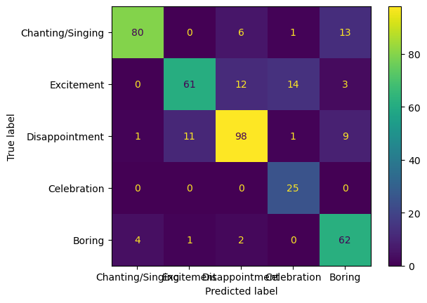

```python
cmd = skm.ConfusionMatrixDisplay(
    skm.confusion_matrix(pred.label_ids, pred.predictions.argmax(1)),
    display_labels = meta.get('labels').keys()
)
cmd.plot()

print(skm.classification_report(pred.label_ids, pred.predictions.argmax(1)))
```

```python
id2label = {v:k for k,v in meta['labels'].items()}
```

```python
print(classification_report(pred.label_ids, pred.predictions.argmax(1)))
```

```
              precision    recall  f1-score   support

           0       0.94      0.80      0.86       100
           1       0.84      0.68      0.75        90
           2       0.83      0.82      0.82       120
           3       0.61      1.00      0.76        25
           4       0.71      0.90      0.79        69

    accuracy                           0.81       404
   macro avg       0.79      0.84      0.80       404
weighted avg       0.83      0.81      0.81       404
```

```python
cm = confusion_matrix(pred.label_ids, pred.predictions.argmax(1), normalize='true')
```

## Normalized Confusion Matrix

This also demonstrates the improved distinction between the two labels.  
'Excitement' is miss identified with 'Dissapointment' and 'CelebrationÄ around 30% of the time. However for human ears it is difficult as well to distinguish the three.

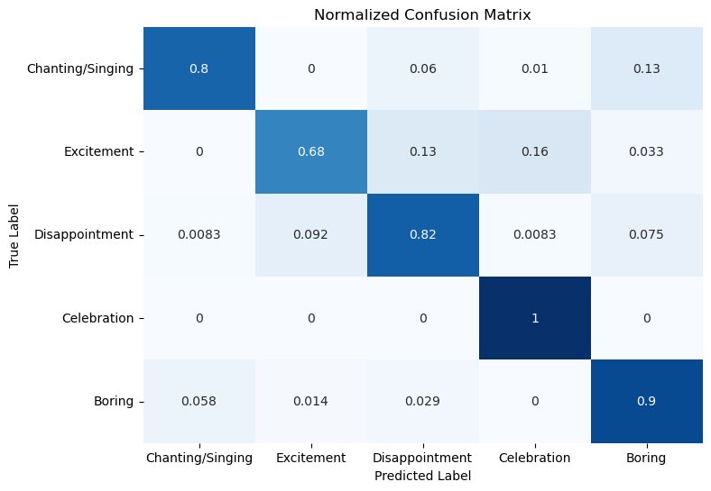

```python
plt.figure(figsize=(8, 6))
sns.heatmap(cm, annot=True, cmap="Blues", cbar=False, xticklabels=id2label.values(), yticklabels=id2label.values())
plt.xlabel("Predicted Label")
plt.ylabel("True Label")
plt.title("Normalized Confusion Matrix")
plt.show()
```

## Conclusion

Although the accuracy has decreased, the overall quality of the model has improved by better distinguishing between the labels "Excitement" and "Disappointment."  
Expanding the augmentation to include "Celebration" did not lead to better performance, which is why augmentation was only applied to "Disappointment" and "Excitement."

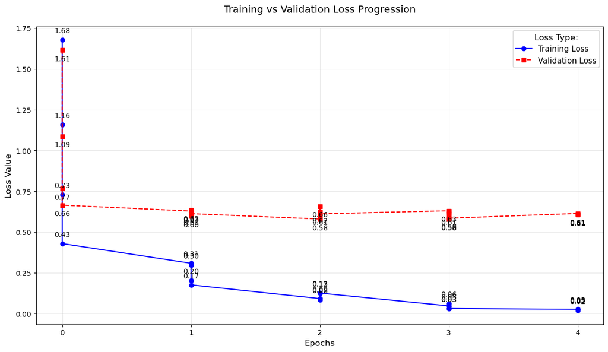

```python
# Collect training and validation metrics
train_epochs = []
train_loss = []
eval_epochs = []
eval_loss = []

for log in trainer.state.log_history:
    if 'loss' in log:
        train_epochs.append(int(log['epoch']))  # Convert to integer epoch
        train_loss.append(log['loss'])
    if 'eval_loss' in log:
        eval_epochs.append(int(log['epoch']))  # Convert to integer epoch
        eval_loss.append(log['eval_loss'])

# Create the plot
plt.figure(figsize=(12, 7))
plt.plot(train_epochs, train_loss, 'bo-', label='Training Loss')
plt.plot(eval_epochs, eval_loss, 'rs--', label='Validation Loss')

# Add plot descriptions
plt.xlabel('Epochs', fontsize=12)
plt.ylabel('Loss Value', fontsize=12)
plt.title('Training vs Validation Loss Progression', fontsize=14, pad=20)
plt.legend(title='Loss Type:', title_fontsize=12, fontsize=11)
plt.grid(True, alpha=0.3)
plt.xticks(np.arange(min(train_epochs), max(train_epochs)+1, 1.0))

# Add axis labels and data point markers
for x,y in zip(train_epochs, train_loss):
    plt.annotate(f"{y:.2f}", (x, y), textcoords="offset points", xytext=(0,10), ha='center')
for x,y in zip(eval_epochs, eval_loss):
    plt.annotate(f"{y:.2f}", (x, y), textcoords="offset points", xytext=(0,-15), ha='center')

plt.tight_layout()
plt.show()
```